# Homework 5

Marcelo Santos Carielo

ago/2023

## Questão - Modelagem das ações da VALE: uma abordagem ARMA-GARCH

*Seguindo o roteiro visto em aula, ajuste modelos GARCH(1, 1), EGARCH(1, 1) e GJR(1, 1) para as ações da VALE, usando as distribuições t-Student e Normal. Verifique qual é o melhor modelo dentre esses, verificando também os resíduos. Apresente previsões para a volatilidade condicional.*

## Resposta

Para este exercício, usaremos a série de retornos do VALE de `01/01/2019` até o dia de hoje (`29-07-29`). O código abaixo coleta esses dados do Yahoo Finance.

```r
library(rugarch)
library(BatchGetSymbols)

# define datas de início e fim
date_init <- "2019-01-01"
date_end <- "2023-07-29"
#date_end <- Sys.Date()

# coleta dados da VALE
tickers <- c("VALE3.SA")
assets <- BatchGetSymbols(tickers=tickers,
                          first.date=date_init,
                          last.date=date_end,
                          type.return="log", # log retorno
                          freq.data="daily")
assets <- assets[[2]]

vale <- assets %>%
  filter(ticker=="VALE3.SA")
```

Agora vemos um resumo estatístico e transformamos os dados para o formato de série temporal:

```r
library(fBasics)

daily_returns_vale <- vale %>%
  select(ref.date, ret.closing.prices)

basicStats(daily_returns_vale$ret.closing.prices)
```

```
##             X..daily_returns_vale.ret.closing.prices
## nobs                                     1137.000000
## NAs                                         1.000000
## Minimum                                    -0.281822
## Maximum                                     0.193574
## 1. Quartile                                -0.013279
## 3. Quartile                                 0.012907
## Mean                                        0.000247
## Median                                      0.000000
## Sum                                         0.280463
## SE Mean                                     0.000784
## LCL Mean                                   -0.001292
## UCL Mean                                    0.001786
## Variance                                    0.000699
## Stdev                                       0.026431
## Skewness                                   -0.775017
## Kurtosis                                   17.355477
```

```r
date <- daily_returns_vale %>%
  select(ref.date) %>%
  rename(date=ref.date) %>%
  slice(-1)

daily_returns_vale <- daily_returns_vale %>%
  select(ret.closing.prices) %>%
  slice(-1)

daily_returns_vale <- as.ts(daily_returns_vale)
```

O resumo estatístico acima mostra que a curtose ficou maior do que 3, indicando que a série analisada possui cauda pesada. Além disso, também notamos que a média ficou por volta de zero. Estes resultados estão dentro do esperado (média zero e cauda pesada).

Vejamos os gráficos do preço diário e do log-retorno da série temporal da VALE.

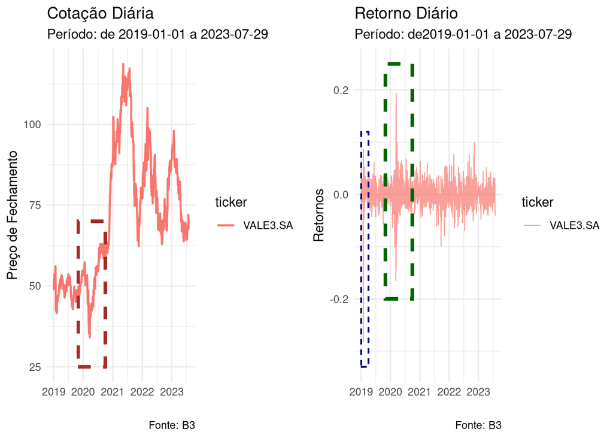

```r
library(ggplot2, quietly=TRUE)
library(gridExtra, quietly=TRUE)

g <- ggplot(data=assets) +
  geom_line(mapping=aes(x=ref.date, y=price.close, color=ticker),
            linewidth=0.8, na.rm=TRUE) +
  geom_rect(aes(xmin=as.Date("2019-11-01"), xmax=as.Date("2020-10-01"),
                ymin=25, ymax=70),
            fill="transparent", linetype=2, color="brown", size=1.2) +
  labs(x="", y="Preço de Fechamento",
       title="Cotação Diária",
       subtitle=paste("Período: de ", date_init, " a ", date_end, sep=""),
       caption="Fonte: B3") +
  theme_minimal()

g.returns <- ggplot(data=assets) +
  geom_line(aes(x=ref.date, y=ret.closing.prices, color=ticker),
            alpha=0.7, linewidth=0.4, na.rm=TRUE) +
  geom_rect(aes(xmin=as.Date("2019-11-01"), xmax=as.Date("2020-10-01"),
                ymin=-0.2, ymax=0.25),
            fill="transparent", linetype=2, color="darkgreen", size=1.2) +
  geom_rect(aes(xmin=as.Date("2019-01-01"), xmax=as.Date("2019-04-01"),
                ymin=-0.33, ymax=0.12),
            fill="transparent", linetype=2, color="darkblue", size=0.5) +
  labs(x="" , y="Retornos",
       title="Retorno Diário",
        subtitle=paste("Período: de", date_init, " a ", date_end, sep=""),
        caption="Fonte: B3") +
    theme_minimal()

grid.arrange(g, g.returns, nrow=1, ncol=2)
```

O gráfico dos retornos mostra o aumento da volatilidade no período de início da pandemia no Brasil. Notamos ainda o início de 2019 também foi um período de alta volatilidade das ações da VALE.

A seguir vamos estimar modelos GARCH(1, 1), EGARCH(1, 1) e GJR(1, 1) para a série de retornos da VALE, usando as distribuições t-Student e Normal.

## TESTE LM

```r
library(FinTS)
ArchTest(daily_returns_vale, lags=1,demean=TRUE)
```

```
##
##  ARCH LM-test; Null hypothesis: no ARCH effects
##
## data:  daily_returns_vale
## Chi-squared = 52.697, df = 1, p-value = 3.891e-13
```

```r
ArchTest(daily_returns_vale, lags=2,demean=TRUE)
```

```
##
##  ARCH LM-test; Null hypothesis: no ARCH effects
##
## data:  daily_returns_vale
## Chi-squared = 75.953, df = 2, p-value < 2.2e-16
```

```r
ArchTest(daily_returns_vale, lags=3,demean=TRUE)
```

```
##
##  ARCH LM-test; Null hypothesis: no ARCH effects
##
## data:  daily_returns_vale
## Chi-squared = 94.783, df = 3, p-value < 2.2e-16
```

```r
ArchTest(daily_returns_vale, lags=5,demean=TRUE)
```

```
##
##  ARCH LM-test; Null hypothesis: no ARCH effects
##
## data:  daily_returns_vale
## Chi-squared = 99.699, df = 5, p-value < 2.2e-16
```

```r
ArchTest(daily_returns_vale, lags=10,demean=TRUE)
```

```
##
##  ARCH LM-test; Null hypothesis: no ARCH effects
##
## data:  daily_returns_vale
## Chi-squared = 103.6, df = 10, p-value < 2.2e-16
```

```r
ArchTest(daily_returns_vale, lags=20,demean=TRUE)
```

```
##
##  ARCH LM-test; Null hypothesis: no ARCH effects
##
## data:  daily_returns_vale
## Chi-squared = 464.59, df = 20, p-value < 2.2e-16
```

### GARCH(1, 1)

Estimamos um modelo GARCH(1, 1) para a série da VALE com o seguinte código:

```r
garch.spec.student <- ugarchspec(variance.model=list(model="sGARCH",
                                                     garchOrder=c(1, 1)),
                                 mean.model=list(armaOrder=c(1, 1),
                                                 include.mean=TRUE),
                                 distribution.model="std")
garch.spec.normal <- ugarchspec(variance.model=list(model="sGARCH",
                                                    garchOrder=c(1, 1)),
                                mean.model=list(armaOrder=c(1, 1),
                                                include.mean=TRUE),
                                distribution.model="norm")

garch.fit.vale.student <- ugarchfit(spec=garch.spec.student,
                                    data=daily_returns_vale)

garch.fit.vale.normal <- ugarchfit(spec=garch.spec.normal,
                                   data=daily_returns_vale)

garch.fit.vale.student
```

```
##
## *---------------------------------*
## *          GARCH Model Fit        *
## *---------------------------------*
##
## Conditional Variance Dynamics
## -----------------------------------
## GARCH Model  : sGARCH(1,1)
## Mean Model   : ARFIMA(1,0,1)
## Distribution : std
##
## Optimal Parameters
## ------------------------------------
##         Estimate  Std. Error  t value Pr(>|t|)
## mu      0.000496    0.000539  0.92035 0.357391
## ar1     0.596578    0.220662  2.70358 0.006860
## ma1    -0.640059    0.210183 -3.04525 0.002325
## omega   0.000071    0.000022  3.16715 0.001539
## alpha1  0.105720    0.030508  3.46529 0.000530
## beta1   0.769408    0.057060 13.48420 0.000000
## shape   5.242010    0.770816  6.80060 0.000000
##
## Robust Standard Errors:
##         Estimate  Std. Error  t value Pr(>|t|)
## mu      0.000496    0.000576  0.86033 0.389605
## ar1     0.596578    0.139434  4.27856 0.000019
## ma1    -0.640059    0.131380 -4.87183 0.000001
## omega   0.000071    0.000019  3.64798 0.000264
## alpha1  0.105720    0.042408  2.49292 0.012670
## beta1   0.769408    0.054136 14.21252 0.000000
## shape   5.242010    1.006414  5.20860 0.000000
##
## LogLikelihood : 2711.734
##
## Information Criteria
## ------------------------------------
##
## Akaike       -4.7619
## Bayes        -4.7308
## Shibata      -4.7619
```

[output cut: 46 more lines]

```
## Negative Sign Bias  0.7736 0.4393
## Positive Sign Bias  0.5772 0.5639
## Joint Effect        1.1813 0.7575
##
##
## Adjusted Pearson Goodness-of-Fit Test:
## ------------------------------------
##   group statistic p-value(g-1)
## 1    20     18.72       0.4750
## 2    30     31.25       0.3536
## 3    40     32.10       0.7752
## 4    50     45.78       0.6045
##
##
## Elapsed time : 0.2241921
```

```r
garch.fit.vale.normal
```

```
##
## *---------------------------------*
## *          GARCH Model Fit        *
## *---------------------------------*
##
## Conditional Variance Dynamics
## -----------------------------------
## GARCH Model  : sGARCH(1,1)
## Mean Model   : ARFIMA(1,0,1)
## Distribution : norm
##
## Optimal Parameters
## ------------------------------------
##         Estimate  Std. Error  t value Pr(>|t|)
## mu      0.000170    0.000637  0.26735 0.789201
## ar1     0.610005    0.343612  1.77527 0.075853
## ma1    -0.645701    0.330404 -1.95427 0.050669
## omega   0.000036    0.000016  2.26934 0.023248
## alpha1  0.049497    0.011640  4.25237 0.000021
## beta1   0.890526    0.032739 27.20103 0.000000
##
## Robust Standard Errors:
##         Estimate  Std. Error  t value Pr(>|t|)
## mu      0.000170    0.000840  0.20276 0.839323
## ar1     0.610005    0.289281  2.10869 0.034971
## ma1    -0.645701    0.277037 -2.33074 0.019767
## omega   0.000036    0.000048  0.76215 0.445968
## alpha1  0.049497    0.048221  1.02646 0.304676
## beta1   0.890526    0.119050  7.48029 0.000000
##
## LogLikelihood : 2605.142
##
## Information Criteria
## ------------------------------------
##
## Akaike       -4.5760
## Bayes        -4.5494
## Shibata      -4.5760
## Hannan-Quinn -4.5659
##
```

[output cut: 43 more lines]

```
## Negative Sign Bias  1.6740 0.0944   *
## Positive Sign Bias  0.1906 0.8489
## Joint Effect        2.8967 0.4078
##
##
## Adjusted Pearson Goodness-of-Fit Test:
## ------------------------------------
##   group statistic p-value(g-1)
## 1    20     63.01    1.279e-06
## 2    30     62.52    2.969e-04
## 3    40     80.27    1.112e-04
## 4    50     86.54    7.540e-04
##
##
## Elapsed time : 0.1061714
```

```
##
## please wait...calculating quantiles...
```

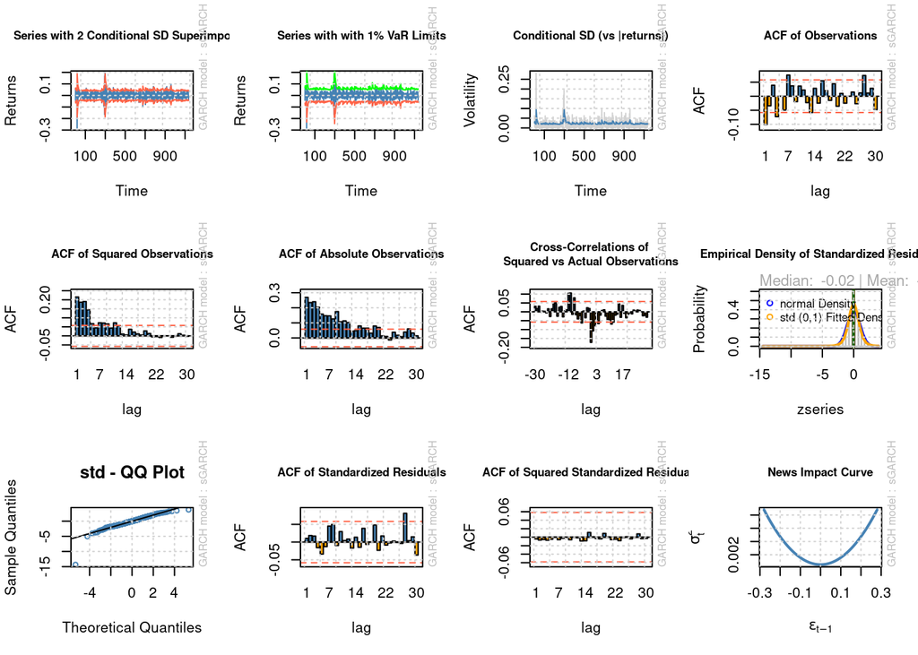

```r
#infocriteria(garch.fit.vale.normal)
#infocriteria(garch.fit.vale.student)
options(repr.plot.width=15, repr.plot.height=15)
plot(garch.fit.vale.student, which="all")
```

```
##
## please wait...calculating quantiles...
```

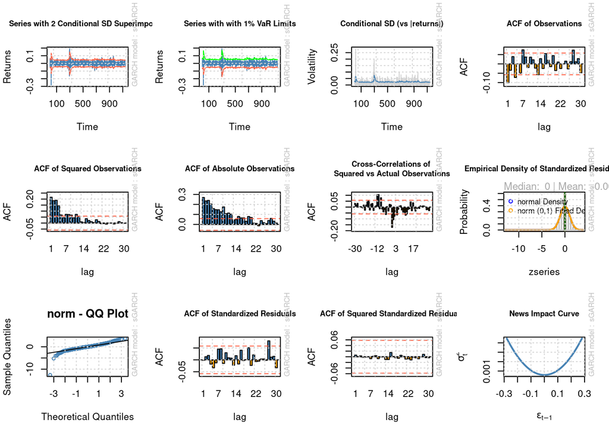

```r
plot(garch.fit.vale.normal, which="all")
```

### EGARCH (Exponential GARCH)

Agora vamos estimar um modelo EGARCH(1, 1) para a mesma série de retornos:

```r
#?ugarchspec
egarch.spec.student <- ugarchspec(variance.model=list(model="eGARCH",
                                                      garchOrder=c(1, 1)),
                                  mean.model=list(armaOrder=c(1, 1),
                                                  include.mean=TRUE),
                                  distribution.model="std")
egarch.spec.normal <- ugarchspec(variance.model=list(model="eGARCH",
                                                     garchOrder=c(1, 1)),
                                mean.model=list(armaOrder=c(1, 1),
                                                include.mean=TRUE),
                                distribution.model="norm")

egarch.fit.vale.student <- ugarchfit(spec=egarch.spec.student,
                                      data=daily_returns_vale)

egarch.fit.vale.normal <- ugarchfit(spec=egarch.spec.normal,
                                   data=daily_returns_vale)

egarch.fit.vale.student
```

```
##
## *---------------------------------*
## *          GARCH Model Fit        *
## *---------------------------------*
##
## Conditional Variance Dynamics
## -----------------------------------
## GARCH Model  : eGARCH(1,1)
## Mean Model   : ARFIMA(1,0,1)
## Distribution : std
##
## Optimal Parameters
## ------------------------------------
##         Estimate  Std. Error   t value Pr(>|t|)
## mu      0.000305    0.000543   0.56107 0.574753
## ar1     0.585531    0.043632  13.41988 0.000000
## ma1    -0.627989    0.042096 -14.91799 0.000000
## omega  -0.556195    0.189119  -2.94098 0.003272
## alpha1 -0.074640    0.026644  -2.80136 0.005089
## beta1   0.926352    0.024950  37.12790 0.000000
## gamma1  0.154126    0.031232   4.93487 0.000001
## shape   5.229301    0.780191   6.70259 0.000000
##
## Robust Standard Errors:
##         Estimate  Std. Error   t value Pr(>|t|)
## mu      0.000305    0.000580   0.52468 0.599807
## ar1     0.585531    0.013036  44.91564 0.000000
## ma1    -0.627989    0.013346 -47.05568 0.000000
## omega  -0.556195    0.278914  -1.99414 0.046137
## alpha1 -0.074640    0.032250  -2.31439 0.020646
## beta1   0.926352    0.036339  25.49216 0.000000
## gamma1  0.154126    0.050332   3.06220 0.002197
## shape   5.229301    1.081064   4.83718 0.000001
##
## LogLikelihood : 2715.315
##
## Information Criteria
## ------------------------------------
##
## Akaike       -4.7664
```

[output cut: 49 more lines]

```
## Negative Sign Bias  0.8171 0.4141
## Positive Sign Bias  0.2752 0.7832
## Joint Effect        1.3735 0.7118
##
##
## Adjusted Pearson Goodness-of-Fit Test:
## ------------------------------------
##   group statistic p-value(g-1)
## 1    20     15.48      0.69171
## 2    30     42.61      0.04945
## 3    40     37.03      0.56011
## 4    50     45.87      0.60095
##
##
## Elapsed time : 0.229763
```

```r
egarch.fit.vale.normal
```

```
##
## *---------------------------------*
## *          GARCH Model Fit        *
## *---------------------------------*
##
## Conditional Variance Dynamics
## -----------------------------------
## GARCH Model  : eGARCH(1,1)
## Mean Model   : ARFIMA(1,0,1)
## Distribution : norm
##
## Optimal Parameters
## ------------------------------------
##         Estimate  Std. Error   t value Pr(>|t|)
## mu      -0.00012    0.000671   -0.1786 0.858252
## ar1      0.67105    0.033818   19.8428 0.000000
## ma1     -0.70271    0.032188  -21.8312 0.000000
## omega   -0.24657    0.001904 -129.5082 0.000000
## alpha1  -0.02485    0.009842   -2.5247 0.011578
## beta1    0.96597    0.000877 1101.2948 0.000000
## gamma1   0.10437    0.008632   12.0906 0.000000
##
## Robust Standard Errors:
##         Estimate  Std. Error   t value Pr(>|t|)
## mu      -0.00012    0.000873  -0.13718  0.89089
## ar1      0.67105    0.013876  48.36205  0.00000
## ma1     -0.70271    0.016219 -43.32565  0.00000
## omega   -0.24657    0.020645 -11.94335  0.00000
## alpha1  -0.02485    0.039845  -0.62366  0.53285
## beta1    0.96597    0.002272 425.17142  0.00000
## gamma1   0.10437    0.015429   6.76430  0.00000
##
## LogLikelihood : 2606.869
##
## Information Criteria
## ------------------------------------
##
## Akaike       -4.5772
## Bayes        -4.5462
## Shibata      -4.5773
```

[output cut: 46 more lines]

```
## Negative Sign Bias 1.84678 0.06504   *
## Positive Sign Bias 0.02883 0.97700
## Joint Effect       3.52288 0.31781
##
##
## Adjusted Pearson Goodness-of-Fit Test:
## ------------------------------------
##   group statistic p-value(g-1)
## 1    20     60.30    3.465e-06
## 2    30     67.38    6.861e-05
## 3    40     98.01    5.514e-07
## 4    50    100.71    1.948e-05
##
##
## Elapsed time : 0.1337895
```

```
##
## please wait...calculating quantiles...
```

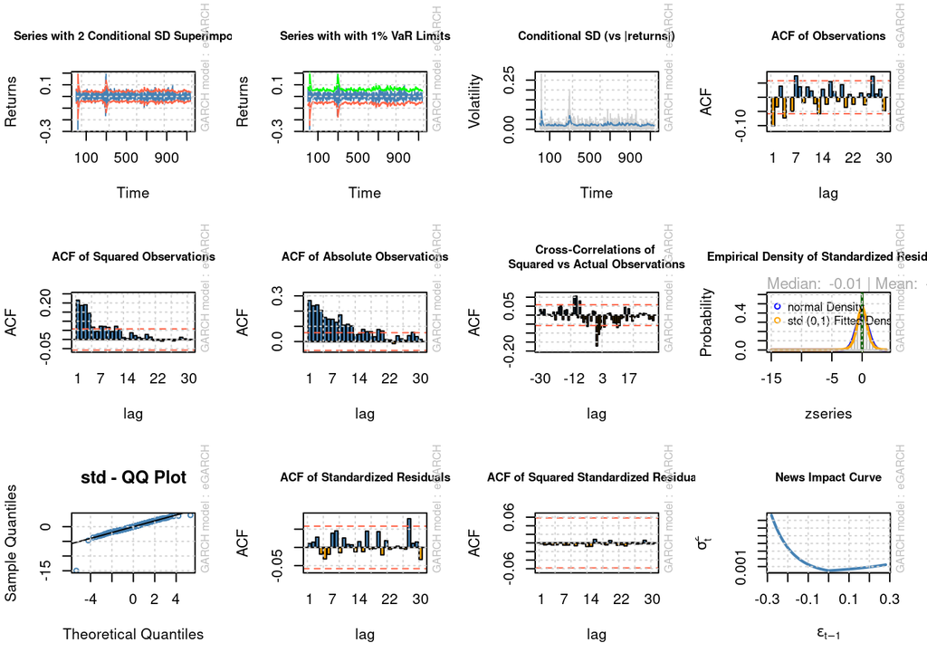

```r
#infocriteria(egarch.fit.vale.normal)
#infocriteria(egarch.fit.vale.student)
options(repr.plot.width=15, repr.plot.height=15)
plot(egarch.fit.vale.student, which="all")
```

```
##
## please wait...calculating quantiles...
```

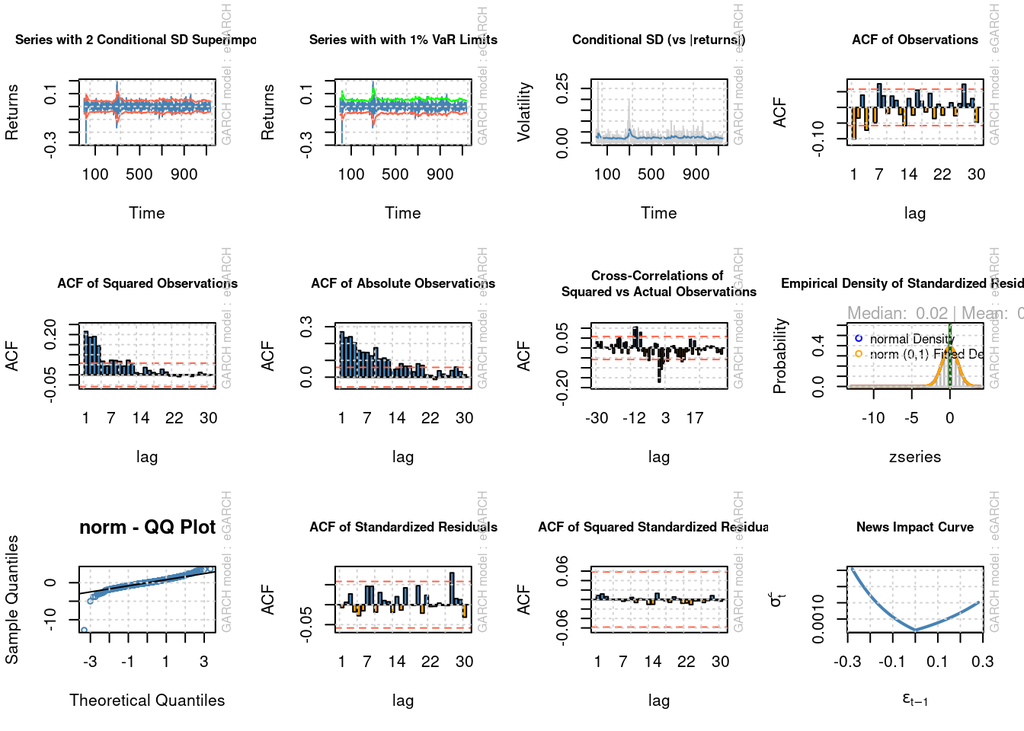

```r
plot(egarch.fit.vale.normal, which="all")
```

### GRJ - GARCH

Agora vamos estimar um modelo GJR(1, 1) para a mesma série de retornos:

```r
#https://search.r-project.org/CRAN/refmans/rugarch/html/ugarchspec-methods.html
gjr_garch.spec.student <- ugarchspec(variance.model=list(model="gjrGARCH",
                                                         garchOrder=c(1, 1)),
                                     mean.model=list(armaOrder=c(1, 1),
                                                     include.mean=TRUE),
                                  distribution.model="std")
gjr_garch.spec.normal <- ugarchspec(variance.model=list(model="gjrGARCH",
                                                        garchOrder=c(1, 1)),
                                    mean.model=list(armaOrder=c(1, 1),
                                                    include.mean=TRUE),
                                    distribution.model="norm")

gjr_garch.fit.vale.student <- ugarchfit(spec=gjr_garch.spec.student,
                                         data=daily_returns_vale)

gjr_garch.fit.vale.normal <- ugarchfit(spec=gjr_garch.spec.normal,
                                        data=daily_returns_vale)

gjr_garch.fit.vale.student
```

```
##
## *---------------------------------*
## *          GARCH Model Fit        *
## *---------------------------------*
##
## Conditional Variance Dynamics
## -----------------------------------
## GARCH Model  : gjrGARCH(1,1)
## Mean Model   : ARFIMA(1,0,1)
## Distribution : std
##
## Optimal Parameters
## ------------------------------------
##         Estimate  Std. Error  t value Pr(>|t|)
## mu      0.000284    0.000545  0.52207 0.601619
## ar1     0.608930    0.218656  2.78487 0.005355
## ma1    -0.650897    0.208302 -3.12478 0.001779
## omega   0.000080    0.000024  3.38724 0.000706
## alpha1  0.037005    0.028160  1.31413 0.188804
## beta1   0.745671    0.060236 12.37906 0.000000
## gamma1  0.160741    0.062026  2.59151 0.009556
## shape   5.408759    0.808587  6.68915 0.000000
##
## Robust Standard Errors:
##         Estimate  Std. Error  t value Pr(>|t|)
## mu      0.000284    0.000579  0.49159 0.623007
## ar1     0.608930    0.140526  4.33321 0.000015
## ma1    -0.650897    0.133325 -4.88204 0.000001
## omega   0.000080    0.000025  3.14669 0.001651
## alpha1  0.037005    0.028117  1.31610 0.188140
## beta1   0.745671    0.067246 11.08868 0.000000
## gamma1  0.160741    0.078331  2.05206 0.040163
## shape   5.408759    1.091120  4.95707 0.000001
##
## LogLikelihood : 2716.723
##
## Information Criteria
## ------------------------------------
##
## Akaike       -4.7689
```

[output cut: 49 more lines]

```
## Negative Sign Bias  0.3262 0.7443
## Positive Sign Bias  0.4071 0.6840
## Joint Effect        0.9644 0.8099
##
##
## Adjusted Pearson Goodness-of-Fit Test:
## ------------------------------------
##   group statistic p-value(g-1)
## 1    20     18.72       0.4750
## 2    30     31.68       0.3343
## 3    40     37.45       0.5406
## 4    50     48.60       0.4895
##
##
## Elapsed time : 0.4059262
```

```r
gjr_garch.fit.vale.normal
```

```
##
## *---------------------------------*
## *          GARCH Model Fit        *
## *---------------------------------*
##
## Conditional Variance Dynamics
## -----------------------------------
## GARCH Model  : gjrGARCH(1,1)
## Mean Model   : ARFIMA(1,0,1)
## Distribution : norm
##
## Optimal Parameters
## ------------------------------------
##         Estimate  Std. Error  t value Pr(>|t|)
## mu      0.000075    0.000640  0.11696 0.906894
## ar1     0.734034    0.225233  3.25900 0.001118
## ma1    -0.763016    0.213002 -3.58220 0.000341
## omega   0.000161    0.000074  2.18110 0.029176
## alpha1  0.011273    0.029757  0.37882 0.704821
## beta1   0.651912    0.151948  4.29036 0.000018
## gamma1  0.167394    0.077494  2.16009 0.030766
##
## Robust Standard Errors:
##         Estimate  Std. Error  t value Pr(>|t|)
## mu      0.000075    0.000696  0.10756 0.914341
## ar1     0.734034    0.204238  3.59401 0.000326
## ma1    -0.763016    0.204093 -3.73858 0.000185
## omega   0.000161    0.000213  0.75387 0.450925
## alpha1  0.011273    0.038657  0.29161 0.770588
## beta1   0.651912    0.399272  1.63275 0.102521
## gamma1  0.167394    0.207350  0.80730 0.419494
##
## LogLikelihood : 2608.582
##
## Information Criteria
## ------------------------------------
##
## Akaike       -4.5802
## Bayes        -4.5492
## Shibata      -4.5803
```

[output cut: 46 more lines]

```
## Negative Sign Bias 0.79740 0.4254
## Positive Sign Bias 0.07324 0.9416
## Joint Effect       1.09455 0.7784
##
##
## Adjusted Pearson Goodness-of-Fit Test:
## ------------------------------------
##   group statistic p-value(g-1)
## 1    20     71.85    4.515e-08
## 2    30     77.26    2.898e-06
## 3    40     86.96    1.630e-05
## 4    50     97.27    4.934e-05
##
##
## Elapsed time : 0.4223883
```

```
##
## please wait...calculating quantiles...
```

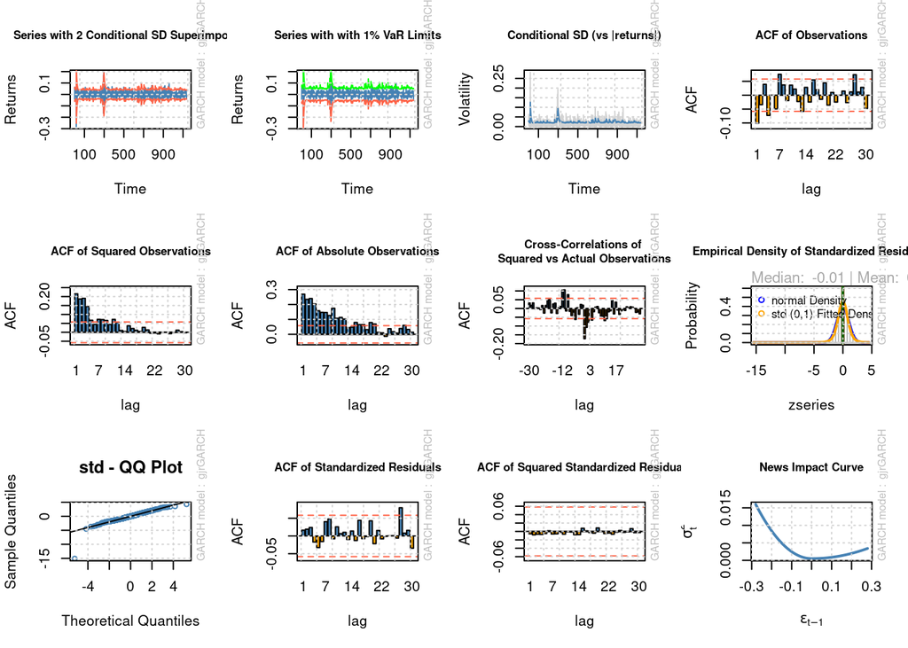

```r
#infocriteria(gjr_garch.fit.vale.normal)
#infocriteria(gjr_garch.fit.vale.student)
options(repr.plot.width=15, repr.plot.height=15)
plot(gjr_garch.fit.vale.student, which="all")
```

```
##
## please wait...calculating quantiles...
```

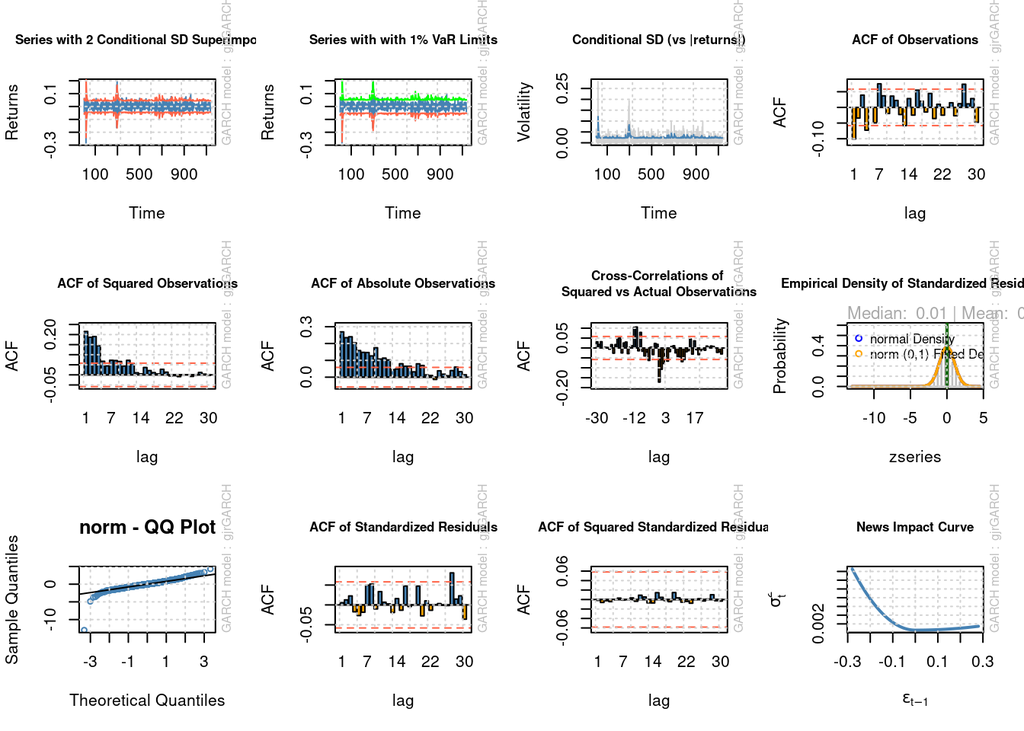

```r
plot(gjr_garch.fit.vale.normal, which="all")
```

## Coeficientes de persistência e *half-life*

Agora vamos calcular os coeficientes de persistência e half-life para cada um dos modelos ajustados acima.

Primeiramente, calculamos os coeficientes de persistência:

```r
paste("garch.normal:", persistence(garch.fit.vale.normal))
```

```
## [1] "garch.normal: 0.940023085058988"
```

```r
paste("garch.student:", persistence(garch.fit.vale.student))
```

```
## [1] "garch.student: 0.875127179811051"
```

```r
paste("egarch.normal:", persistence(egarch.fit.vale.normal))
```

```
## [1] "egarch.normal: 0.965965583402948"
```

```r
paste("egarch.student:", persistence(egarch.fit.vale.student))
```

```
## [1] "egarch.student: 0.926351723034298"
```

```r
paste("gjr_garch.normal:", persistence(gjr_garch.fit.vale.normal))
```

```
## [1] "gjr_garch.normal: 0.746881897221491"
```

```r
paste("gjr_garch.student:", persistence(gjr_garch.fit.vale.student))
```

```
## [1] "gjr_garch.student: 0.863046388509446"
```

Os valores acima indicam que haverá maior pesistência dos choques no caso de usarmos o modelo EGARCH(1, 1) com distribuição Normal (`egarch.normal`). Ou seja, escolhendo este modelo haverá uma maior persistência da volatilidade.

Por outro lado, escolhendo o GJR(1, 1) com distribuição Normal (`gjr_garch.normal`) haverá uma menor persistência da volatilidade.

Calculamos os coeficientes de *half-life* com os códigos abaixo:

```r
paste("garch.normal:", halflife(garch.fit.vale.normal))
```

```
## [1] "garch.normal: 11.2067535303504"
```

```r
paste("garch.student:", halflife(garch.fit.vale.student))
```

```
## [1] "garch.student: 5.19654908031971"
```

```r
paste("egarch.normal:", halflife(egarch.fit.vale.normal))
```

```
## [1] "egarch.normal: 20.0174924840579"
```

```r
paste("egarch.student:", halflife(egarch.fit.vale.student))
```

```
## [1] "egarch.student: 9.06059514996847"
```

```r
paste("gjr_garch.normal:", halflife(gjr_garch.fit.vale.normal))
```

```
## [1] "gjr_garch.normal: 2.37502632831976"
```

```r
paste("gjr_garch.student:", halflife(gjr_garch.fit.vale.student))
```

```
## [1] "gjr_garch.student: 4.70610406178515"
```

Pelos valores acima, notamos que com a escolha do modelo GRJ(1, 1) com distribuição Normal (`gjr_garch.normal`), modelo correspondente ao menor valor de *half-time*, teremos uma menor quantidade de dias (cerca de 2 dias) para o choque ser dissipado pela metade.

## Critério de Informação

Agora iremos calcular os critérios de informação de Akaike, Bayesiano (Schwarz), Shibata e Hannan-Quinn para dos nossos modelos:

```r
print("garch.fit.vale.normal:")
```

```
## [1] "garch.fit.vale.normal:"
```

```r
infocriteria(garch.fit.vale.normal)
```

```
##
## Akaike       -4.575955
## Bayes        -4.549360
## Shibata      -4.576010
## Hannan-Quinn -4.565910
```

```r
print("garch.fit.vale.student:")
```

```
## [1] "garch.fit.vale.student:"
```

```r
infocriteria(garch.fit.vale.student)
```

```
##
## Akaike       -4.761855
## Bayes        -4.730828
## Shibata      -4.761930
## Hannan-Quinn -4.750136
```

```r
print("egarch.fit.vale.normal:")
```

```
## [1] "egarch.fit.vale.normal:"
```

```r
infocriteria(egarch.fit.vale.normal)
```

```
##
## Akaike       -4.577233
## Bayes        -4.546206
## Shibata      -4.577309
## Hannan-Quinn -4.565514
```

```r
print("egarch.fit.vale.student:")
```

```
## [1] "egarch.fit.vale.student:"
```

```r
infocriteria(egarch.fit.vale.student)
```

```
##
## Akaike       -4.766400
## Bayes        -4.730940
## Shibata      -4.766498
## Hannan-Quinn -4.753006
```

```r
print("gjr_garch.fit.vale.normal:")
```

```
## [1] "gjr_garch.fit.vale.normal:"
```

```r
infocriteria(gjr_garch.fit.vale.normal)
```

```
##
## Akaike       -4.580250
## Bayes        -4.549223
## Shibata      -4.580325
## Hannan-Quinn -4.568531
```

```r
print("gjr_garch.fit.vale.student:")
```

```
## [1] "gjr_garch.fit.vale.student:"
```

```r
infocriteria(gjr_garch.fit.vale.student)
```

```
##
## Akaike       -4.768878
## Bayes        -4.733419
## Shibata      -4.768977
## Hannan-Quinn -4.755485
```

### Critério de Informação - Resumo

| Modelo | Akaike | Bayes | Shibata | Hannan-Quinn |
| --- | --- | --- | --- | --- |
| garch.fit.vale.normal | -4.575955 | -4.549360 | -4.576010 | -4.565910 |
| garch.fit.vale.student | -4.761855 | -4.730828 | -4.761930 | -4.750136 |
| egarch.fit.vale.normal | -4.577233 | -4.546206 | -4.577309 | -4.565514 |
| egarch.fit.vale.student | -4.766400 | -4.730940 | -4.766498 | -4.753006 |
| gjr_garch.fit.vale.normal | -4.580250 | -4.549223 | -4.580325 | -4.568531 |
| gjr_garch.fit.vale.student | **-4.768878** | **-4.733419** | **-4.768977** | **-4.755485** |

Como na tabela acima o modelo GJR(1,1) com t-Student obteve os menores valores para cada um dos critérios de informação apresentados, escolhemos este modelo (`gjr_garch.fit.vale.student`) para prosseguirmos as análises.

## Resíduos

Vejamos a ACF dos resíduos:

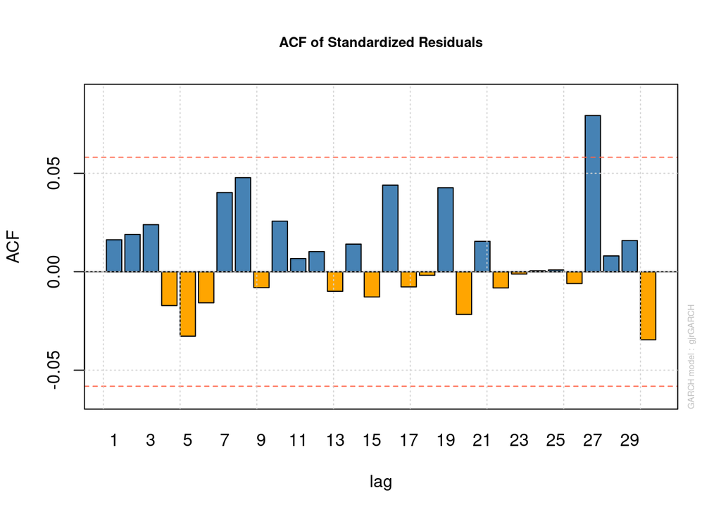

```r
options(repr.plot.width=25, repr.plot.height=15)
#plot(gjr_garch.fit.vale.student, which="all")
plot(gjr_garch.fit.vale.student, which=10)
```

Vejamos os resíduos ao quadrado:

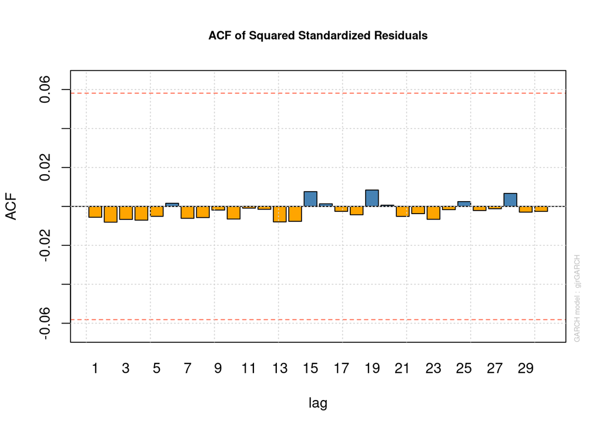

```r
options(repr.plot.width=25, repr.plot.height=15)
#plot(gjr_garch.fit.vale.student, which="all")
plot(gjr_garch.fit.vale.student, which=11)
```

Para os resíduos ao quadrado não notamos autocorrelação significativa para nenhum dos lags exibidos no gráfico.

## Volatilidade condicional

A seguir temos o gráfico da volatilidade condicional para o modelo selecionado acima:

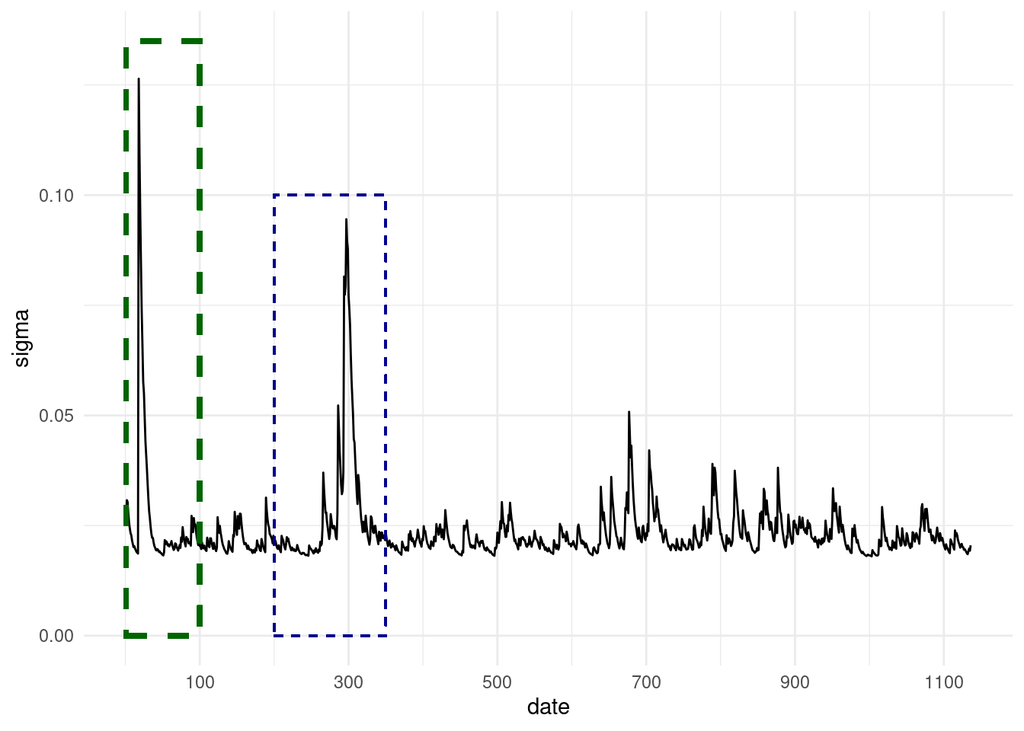

```r
library(tbl2xts)
sigma <- sigma(gjr_garch.fit.vale.student) %>% xts_tbl()
colnames(sigma) <- c("date", "sigma")
sigma <- sigma %>% mutate(date=as.Date(date))
#sigma$date
ggplot(sigma) + geom_line(aes(x=date , y=sigma)) +
  geom_rect(aes(xmin=as.Date("1-01-01"), xmax=as.Date("100-01-01"),
                ymin=0, ymax=0.135),
            fill="transparent", linetype=2, color="darkgreen", size=1.2) +
  geom_rect(aes(xmin=as.Date("200-01-01"), xmax=as.Date("350-01-01"),
                ymin=0, ymax=0.100),
            fill="transparent", linetype=2, color="darkblue", size=0.5) +
  theme_minimal()
```

Nos trechos destacados no gráfico acima temos um aumento na volatilidade. Os períodos correspondem ao início de 2019 e ao início da pandemia.

## Previsões para volatilidade condicional

Usando o modelo GJR(1, 1) com t-Student `gjr_garch.fit.vale.student` estimado acima, realizamos a predição para volatilidade condicional 42 passos a frente:

```r
garchf.1 <- ugarchforecast(gjr_garch.fit.vale.student, n.ahead=42)
garchf.1
```

```
##
## *------------------------------------*
## *       GARCH Model Forecast         *
## *------------------------------------*
## Model: gjrGARCH
## Horizon: 42
## Roll Steps: 0
## Out of Sample: 0
##
## 0-roll forecast [T0=1136-01-01]:
##         Series   Sigma
## T+1  0.0019883 0.02686
## T+2  0.0013220 0.02651
## T+3  0.0009163 0.02620
## T+4  0.0006692 0.02593
## T+5  0.0005187 0.02569
## T+6  0.0004271 0.02549
## T+7  0.0003714 0.02531
## T+8  0.0003374 0.02516
## T+9  0.0003167 0.02503
## T+10 0.0003041 0.02491
## T+11 0.0002964 0.02481
## T+12 0.0002918 0.02472
## T+13 0.0002889 0.02465
## T+14 0.0002872 0.02458
## T+15 0.0002861 0.02453
## T+16 0.0002855 0.02448
## T+17 0.0002851 0.02443
## T+18 0.0002849 0.02440
## T+19 0.0002847 0.02437
## T+20 0.0002846 0.02434
## T+21 0.0002846 0.02432
## T+22 0.0002845 0.02429
## T+23 0.0002845 0.02428
## T+24 0.0002845 0.02426
## T+25 0.0002845 0.02425
## T+26 0.0002845 0.02424
## T+27 0.0002845 0.02423
## T+28 0.0002845 0.02422
## T+29 0.0002845 0.02421
## T+30 0.0002845 0.02421
## T+31 0.0002845 0.02420
## T+32 0.0002845 0.02420
## T+33 0.0002845 0.02419
## T+34 0.0002845 0.02419
## T+35 0.0002845 0.02419
## T+36 0.0002845 0.02418
## T+37 0.0002845 0.02418
## T+38 0.0002845 0.02418
## T+39 0.0002845 0.02418
## T+40 0.0002845 0.02418
## T+41 0.0002845 0.02417
## T+42 0.0002845 0.02417
```

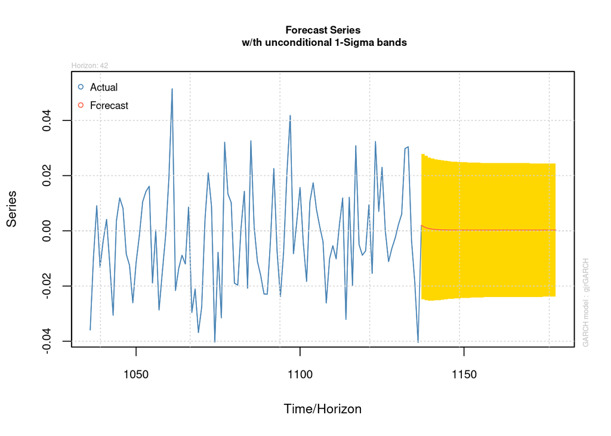

```r
plot(garchf.1, which=1)
```

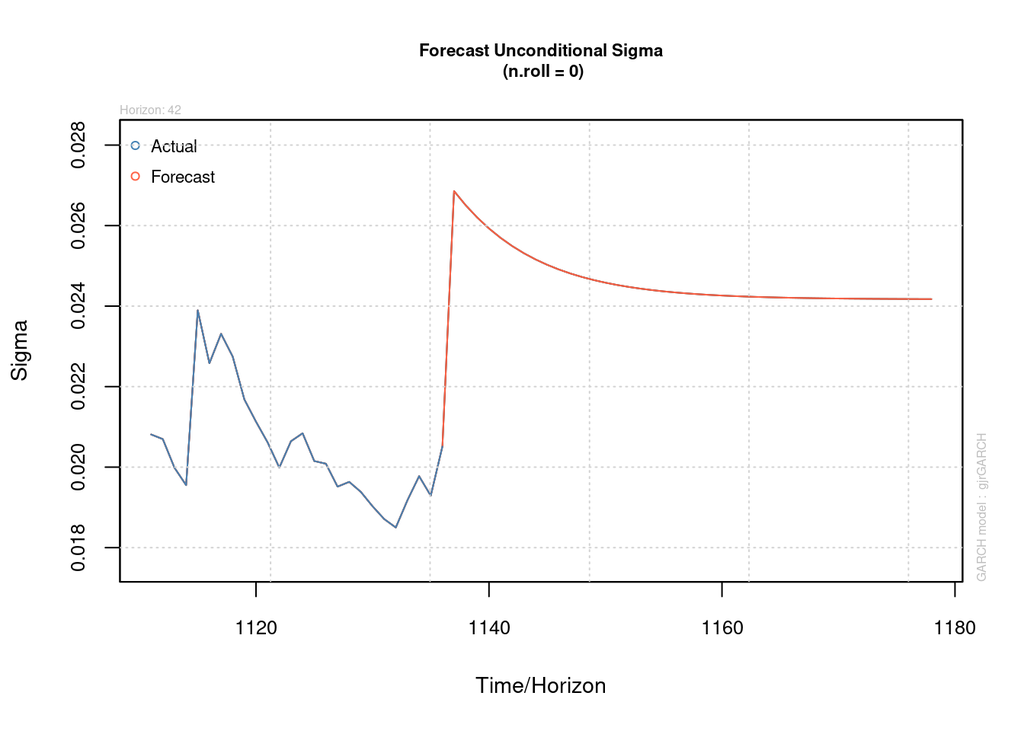

```r
plot(garchf.1, which=3)
```

Pelos gráficos notamos que para os próximos 42 dias haverá um aumento na volatilidade, que tenderá a se estabilizar em um valor mais alto que o dos últimos dias. Por sua vez, a média continuará por volta de zero.

## Referências

- Materiais das aulas (profa. Andreza Palma)
- CAP. 4 do livro “TSAY, Ruey S. *An introduction to analysis of financial data with R.* John Wiley & Sons, 2014.”